# Exploratory visualization

September 2021

## Graphics for inference

- What is my model telling me?
- How can I tell other people?

## Principles

- Graphs tell stories better than tables do
  - Use graphs to illustrate comparisons
  - Be careful about *units*
- Distinguish between (scientific) variables and (statistical) parameters
- Keep P values in their place
- Show data if it doesn’t interfere

## Smoking data

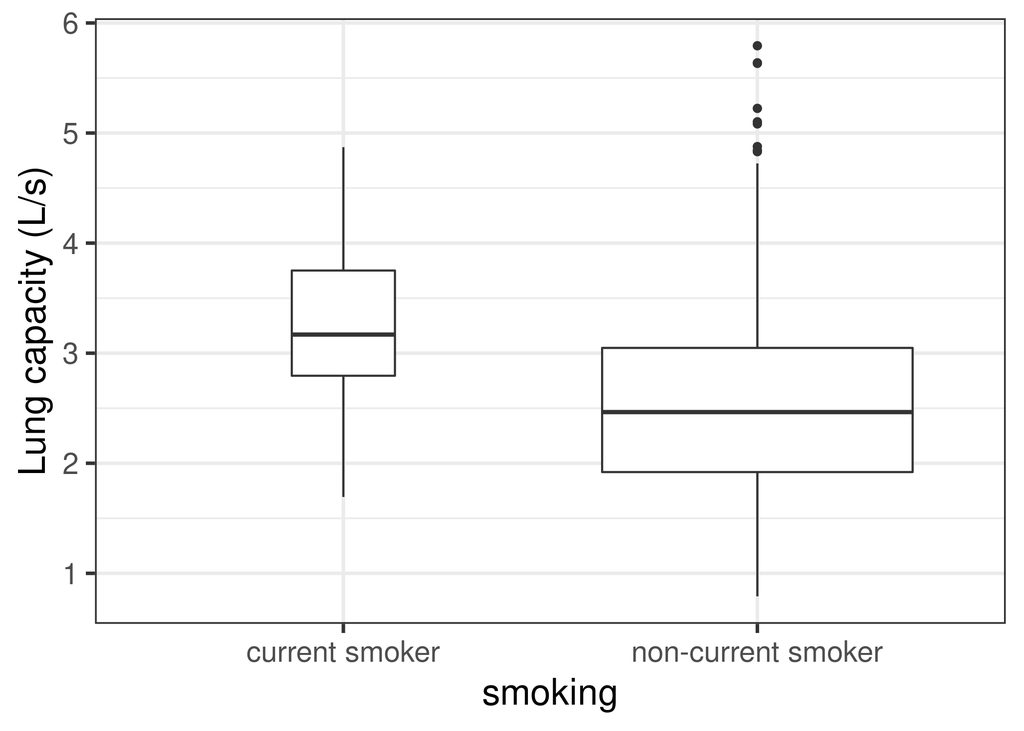

## Smoking data

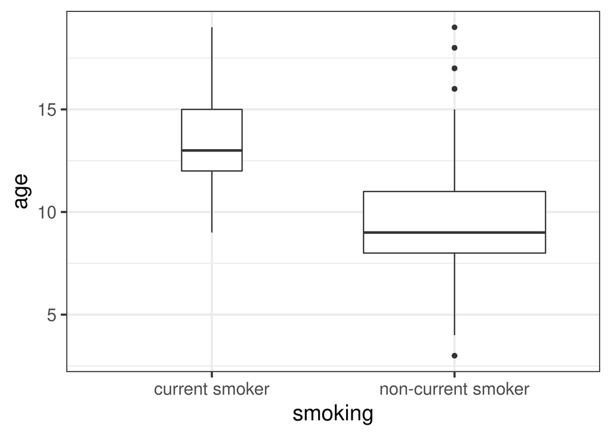

## Smoking data

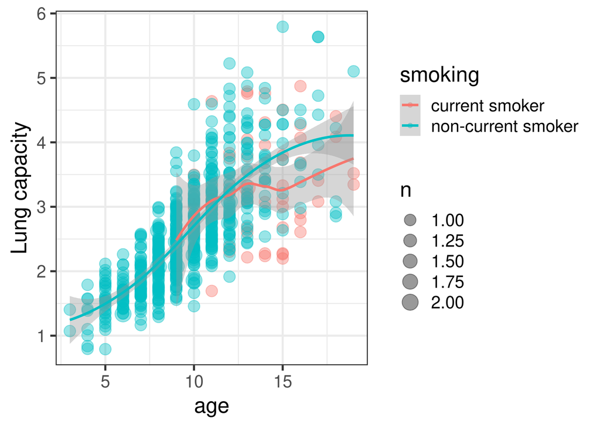

## Smoking inference

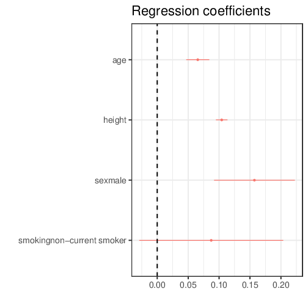

- Different units *Bad*

## Smoking inference

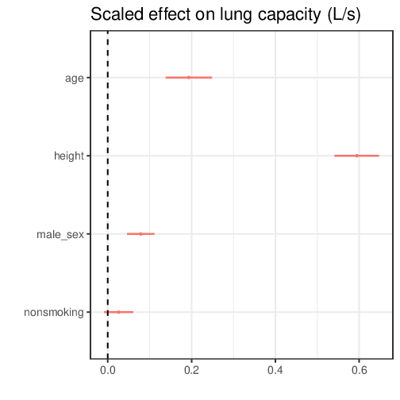

## Smoking inference

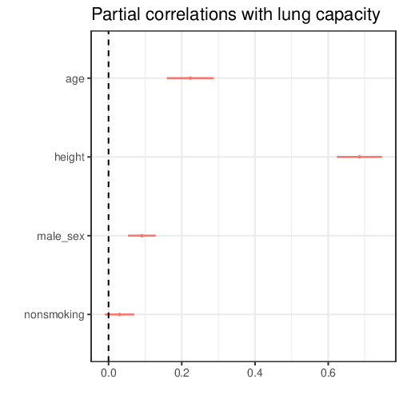

- Would P values add anything here?

## Comparing effects on different response variables

- Put response variables on same scale:
  - Standardize
  - Logs
  - Proportions

## Shape of response

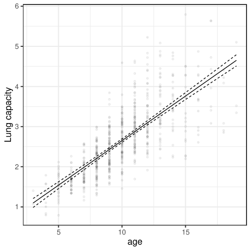

## Standard prediction plot

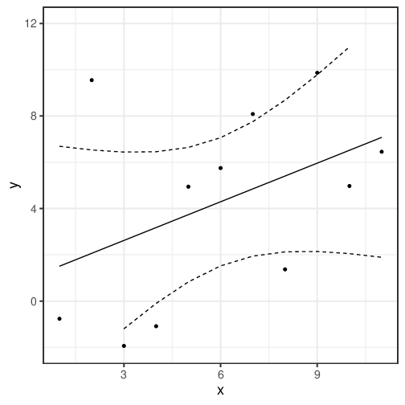

## Marginal prediction plot

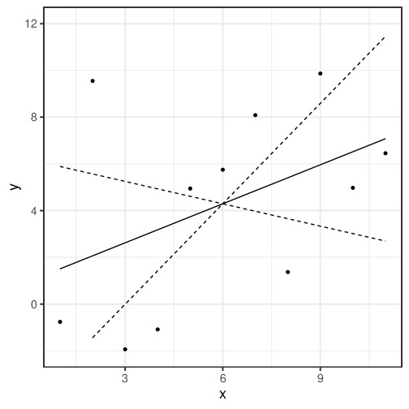

## Combined

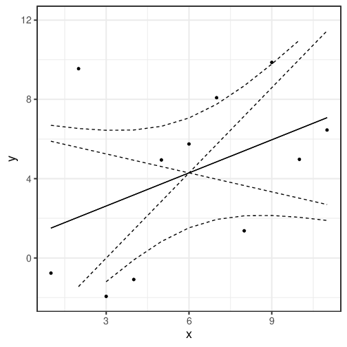

## Variables vs. parameters

- A coefficient plot is most useful when each *variable* corresponds to a single statistical *parameter*
  - Binary predictor
  - Linear predictor
- More detailed shape information should be preferred when there is more than one parameter for a single logical variable
  - More than two categories
  - Splines and polynomials

## No standard approach

- There are many different ways to try to capture marginal effects of a single variable
  - Particularly if it’s associated with more than one parameter
- JD likes to calculate from the model “center”
  - This is the average value from each predictor column of the model matrix
  - Relatively stable
  - A bit divorced from physical reality

## Prediction plots

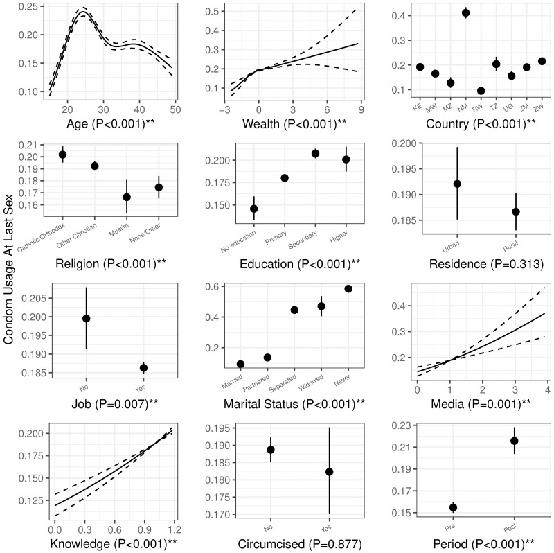

## P values

- We use variable-level P values as a standard for whether the *overall* pattern associated with a given variable is significant
  - This is not super-easy to interpret
  - But it is also not super-easy to think of a better alternative

## Interactions

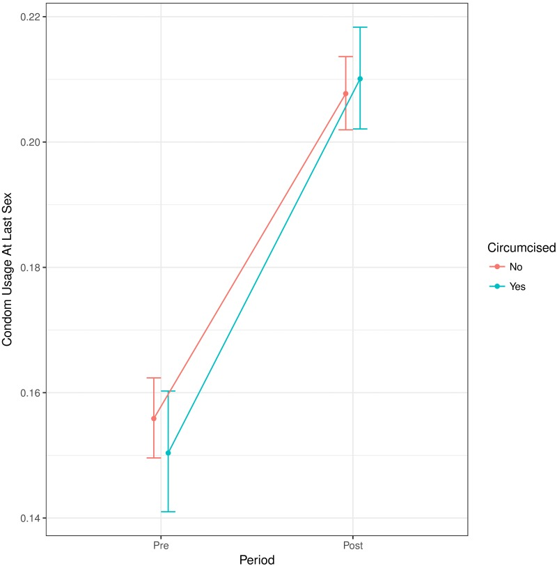

## Scales and transformations

- Your model will often involve an original scale (where the data are collected) and a link scale (where the linear predictor lives)
- Which scale should you use for:
  - Calculations?
  - Displaying numbers to users?
  - Graphing?